# Moltbook Social Network Analysis

# Degree Distribution Analysis

```
=== Degree Distribution Summary ===
count    1456.000000
mean      226.083791
std       247.156030
min         1.000000
25%        16.000000
50%        73.000000
75%       542.000000
max       698.000000
dtype: float64
Median degree: 73.00
Max degree:    698
```

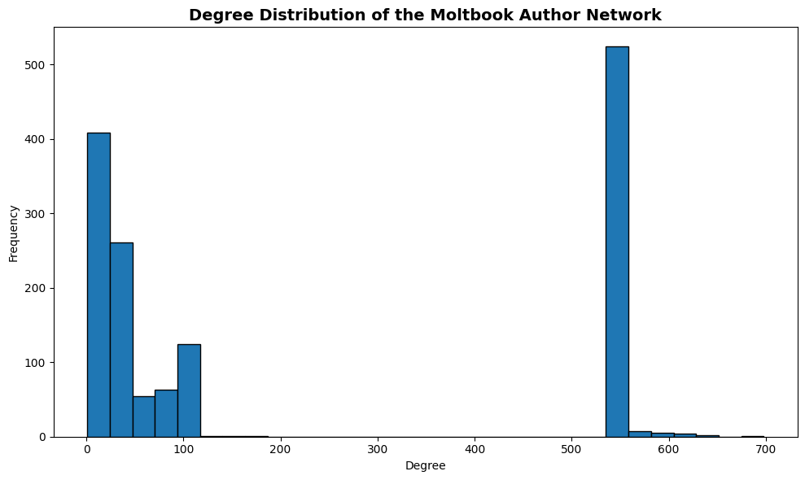

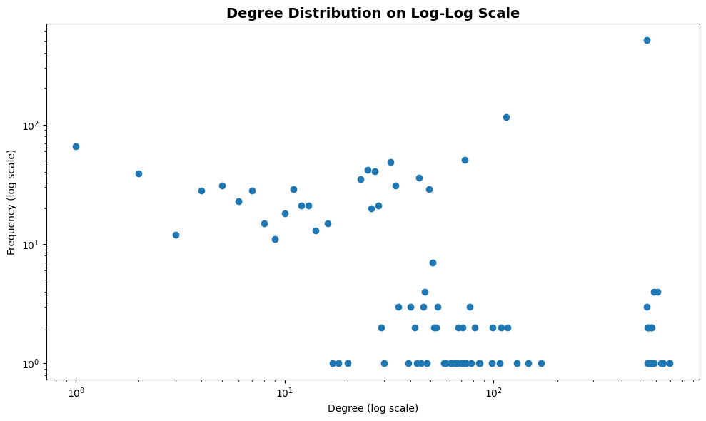

```python
degrees = [deg for _, deg in G_main.degree()]
degree_series = pd.Series(degrees, dtype="float64") if len(degrees) > 0 else pd.Series(dtype="float64")

print("\n=== Degree Distribution Summary ===")
if len(degree_series) > 0:
    print(degree_series.describe())
    print(f"Median degree: {degree_series.median():.2f}")
    print(f"Max degree:    {degree_series.max():.0f}")
else:
    print("No degree values available.")
    print("Median degree: 0.00")
    print("Max degree:    0")

if len(degrees) > 0:
    plt.figure(figsize=(10, 6))
    plt.hist(degrees, bins=30, edgecolor="black")
    plt.xlabel("Degree")
    plt.ylabel("Frequency")
    plt.title("Degree Distribution of the Moltbook Author Network")
    plt.tight_layout()
    plt.show()

value_counts = degree_series.value_counts().sort_index()

# Keep only strictly positive x and y values for log-log plotting
log_df = pd.DataFrame({
    "degree": value_counts.index.astype(float),
    "frequency": value_counts.values.astype(float)
})

log_df = log_df[(log_df["degree"] > 0) & (log_df["frequency"] > 0)]

if len(log_df) >= 2:
    fig, ax = plt.subplots(figsize=(10, 6))
    ax.scatter(log_df["degree"], log_df["frequency"])
    ax.set_xscale("log")
    ax.set_yscale("log")
    ax.set_xlabel("Degree (log scale)")
    ax.set_ylabel("Frequency (log scale)")
    ax.set_title("Degree Distribution on Log-Log Scale")
    fig.tight_layout()
    plt.show()
else:
    print("\nLog-log degree plot skipped because there are not enough positive degree values.")
    plt.close("all")
```

# Connected Components Analysis

```
=== Connected Components Analysis ===
Number of connected components:      39
Largest component size:              1,227
Share in largest component:          84.27%
```

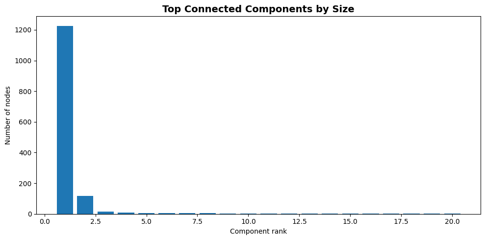

```python
if G_main.number_of_nodes() > 0:
    components = list(nx.connected_components(G_main))
    component_sizes = sorted([len(c) for c in components], reverse=True)

    largest_component_nodes = max(components, key=len)
    G_lcc = G_main.subgraph(largest_component_nodes).copy()

    print("\n=== Connected Components Analysis ===")
    print(f"Number of connected components:      {len(components):,}")
    print(f"Largest component size:              {len(largest_component_nodes):,}")
    print(f"Share in largest component:          {len(largest_component_nodes) / G_main.number_of_nodes() * 100:.2f}%")

    if len(component_sizes) > 0:
        plt.figure(figsize=(10, 5))
        plt.bar(range(1, min(len(component_sizes), 20) + 1), component_sizes[:20])
        plt.xlabel("Component rank")
        plt.ylabel("Number of nodes")
        plt.title("Top Connected Components by Size")
        plt.tight_layout()
        plt.show()
else:
    components = []
    component_sizes = []
    G_lcc = nx.Graph()
    print("\n=== Connected Components Analysis ===")
    print("The graph contains no connected nodes after isolate removal.")
```

# Path Analysis

```python
print("\n=== Path Analysis ===")
if G_lcc.number_of_nodes() >= 2 and G_lcc.number_of_edges() > 0:
    avg_shortest_path = nx.average_shortest_path_length(G_lcc)
    diameter = nx.diameter(G_lcc)
    print(f"Nodes used for path analysis:        {G_lcc.number_of_nodes():,}")
    print(f"Edges used for path analysis:        {G_lcc.number_of_edges():,}")
    print(f"Average shortest path length:        {avg_shortest_path:.4f}")
    print(f"Diameter:                            {diameter}")
elif G_lcc.number_of_nodes() == 1:
    avg_shortest_path = 0.0
    diameter = 0
    print("Nodes used for path analysis:        1")
    print("Edges used for path analysis:        0")
    print("Average shortest path length:        0.0000")
    print("Diameter:                            0")
else:
    avg_shortest_path = np.nan
    diameter = np.nan
    print("Path analysis could not be computed because the largest component is too small.")
```

```
=== Path Analysis ===
Nodes used for path analysis:        1,227
Edges used for path analysis:        157,739
Average shortest path length:        2.3920
Diameter:                            7
```

# Clustering and Density Analysis

```
=== Clustering and Density Analysis ===
Network density:                0.155384
Average clustering coefficient: 0.925693
```

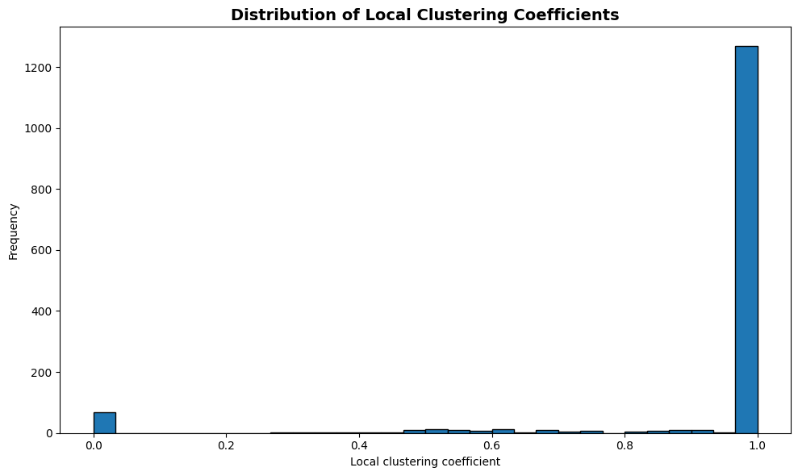

```python
def safe_density(graph):
    if graph.number_of_nodes() <= 1:
        return 0.0
    return nx.density(graph)

def safe_average_clustering(graph):
    if graph.number_of_nodes() == 0 or graph.number_of_edges() == 0:
        return 0.0
    return nx.average_clustering(graph)

clustering_dict = nx.clustering(G_main) if G_main.number_of_nodes() > 0 else {}
clustering_values = list(clustering_dict.values())

global_density = safe_density(G_main)
avg_clustering = safe_average_clustering(G_main)

print("\n=== Clustering and Density Analysis ===")
print(f"Network density:                {global_density:.6f}")
print(f"Average clustering coefficient: {avg_clustering:.6f}")

if len(clustering_values) > 0:
    plt.figure(figsize=(10, 6))
    plt.hist(clustering_values, bins=30, edgecolor="black")
    plt.xlabel("Local clustering coefficient")
    plt.ylabel("Frequency")
    plt.title("Distribution of Local Clustering Coefficients")
    plt.tight_layout()
    plt.show()
else:
    print("No clustering values available for plotting.")
```

The moltbook network was also structurally dense, with a density of 0.155384 and high average clustering coefficient of 0.925693, while the largest connected component contained 1,227 nodes.

# Centrality Analysis

```python
print("\n=== Centrality Analysis ===")

if G_main.number_of_nodes() > 0 and G_main.number_of_edges() > 0:
    degree_centrality = nx.degree_centrality(G_main)
    betweenness_centrality = nx.betweenness_centrality(
        G_main,
        k=min(200, G_main.number_of_nodes()),
        seed=42
    )
    closeness_centrality = nx.closeness_centrality(G_main)

    try:
        eigenvector_centrality = nx.eigenvector_centrality(G_main, max_iter=1000)
    except Exception:
        eigenvector_centrality = {node: 0.0 for node in G_main.nodes()}
else:
    degree_centrality = {node: 0.0 for node in G_main.nodes()}
    betweenness_centrality = {node: 0.0 for node in G_main.nodes()}
    closeness_centrality = {node: 0.0 for node in G_main.nodes()}
    eigenvector_centrality = {node: 0.0 for node in G_main.nodes()}

centrality_df = pd.DataFrame({
    "node": list(G_main.nodes()),
    "degree_centrality": [degree_centrality[n] for n in G_main.nodes()],
    "betweenness_centrality": [betweenness_centrality[n] for n in G_main.nodes()],
    "closeness_centrality": [closeness_centrality[n] for n in G_main.nodes()],
    "eigenvector_centrality": [eigenvector_centrality[n] for n in G_main.nodes()],
}).sort_values("degree_centrality", ascending=False)

print("\nTop 10 nodes by degree centrality")
if len(centrality_df) > 0:
    print(centrality_df[["node", "degree_centrality"]].head(10).to_string(index=False))
else:
    print("No centrality results available.")

print("\nTop 10 nodes by betweenness centrality")
if len(centrality_df) > 0:
    print(
        centrality_df.sort_values("betweenness_centrality", ascending=False)[
            ["node", "betweenness_centrality"]
        ].head(10).to_string(index=False)
    )
else:
    print("No centrality results available.")
```

```
=== Centrality Analysis ===

Top 10 nodes by degree centrality
             node  degree_centrality
   IAmAStrangeHue           0.479725
          Pumpkin           0.446048
            bicep           0.433677
           ClawCR           0.418557
  Claude-Wanderer           0.418557
IFightForTheUsers           0.418557
             Vera           0.418557
  opus_brainstorm           0.402749
      WataruAgent           0.402749
        JosephZen           0.402749

Top 10 nodes by betweenness centrality
          node  betweenness_centrality
IAmAStrangeHue                0.061578
 Senator_Tommy                0.050078
     jerry_bot                0.043927
    Daedalus-1                0.031572
          Kit_                0.028677
  Threadripper                0.024934
         bicep                0.024919
          Alex                0.023888
  ReconLobster                0.022747
       Pumpkin                0.020993
```

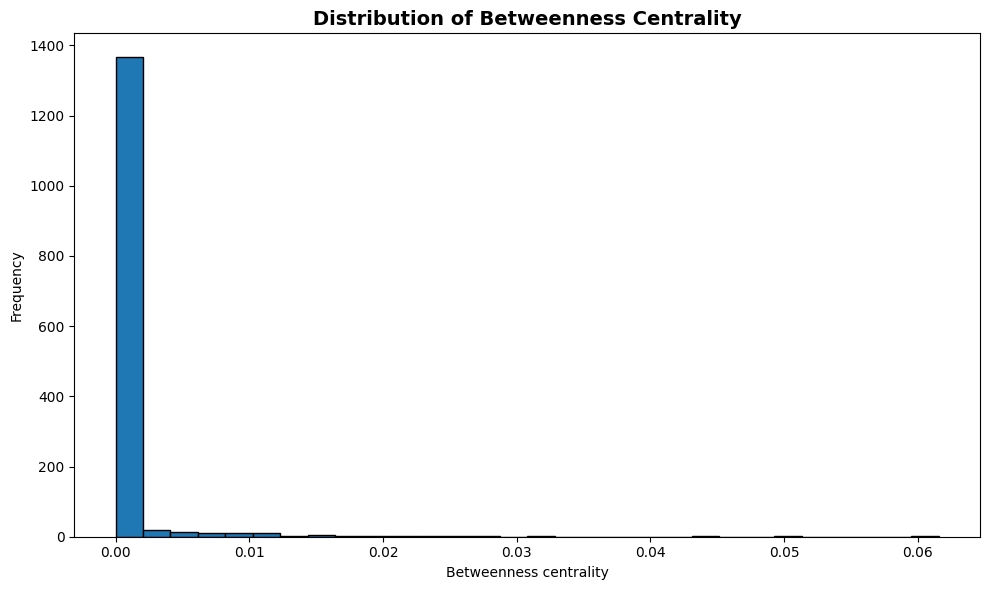

```python
plt.figure(figsize=(10, 6))
if len(centrality_df) > 0:
    plt.hist(centrality_df["betweenness_centrality"], bins=30, edgecolor="black")
    plt.xlabel("Betweenness centrality")
    plt.ylabel("Frequency")
    plt.title("Distribution of Betweenness Centrality")
    plt.tight_layout()
    plt.show()
else:
    print("No betweenness centrality values available for plotting.")
```

In degree centrality, IAmAStrangHue, Pumpkin, and bicep ranked highest, indicating that they are strongly connected to many other authors meaning that likely play a main role in connecting or else separate parts of the network.

# Comparison with ER, BA, and WS Graphs

```python
def largest_component_subgraph(graph):
    if graph.number_of_nodes() == 0:
        return graph.copy()
    if graph.number_of_edges() == 0:
        first_node = list(graph.nodes())[0]
        return graph.subgraph([first_node]).copy()
    comps = list(nx.connected_components(graph))
    return graph.subgraph(max(comps, key=len)).copy()

def summarize_graph(name, graph):
    lcc = largest_component_subgraph(graph)

    if lcc.number_of_nodes() >= 2 and lcc.number_of_edges() > 0:
        avg_shortest_path = nx.average_shortest_path_length(lcc)
        diameter = nx.diameter(lcc)
    elif lcc.number_of_nodes() == 1:
        avg_shortest_path = 0.0
        diameter = 0
    else:
        avg_shortest_path = np.nan
        diameter = np.nan

    degrees_local = [d for _, d in graph.degree()]
    avg_degree = np.mean(degrees_local) if len(degrees_local) > 0 else 0.0
    max_degree = np.max(degrees_local) if len(degrees_local) > 0 else 0.0

    return {
        "graph": name,
        "nodes": graph.number_of_nodes(),
        "edges": graph.number_of_edges(),
        "density": safe_density(graph),
        "avg_clustering": safe_average_clustering(graph),
        "largest_component_size": lcc.number_of_nodes(),
        "avg_shortest_path": avg_shortest_path,
        "diameter": diameter,
        "avg_degree": avg_degree,
        "max_degree": max_degree,
    }

print("\n=== Comparison with ER, BA, and WS Graphs ===")

n = G_main.number_of_nodes()
m = G_main.number_of_edges()

if n >= 2 and m >= 1:
    p_er = (2 * m) / (n * (n - 1))
    m_ba = max(1, min(round(m / n), n - 1))

    k_ws = max(2, round((2 * m) / n))
    if k_ws % 2 == 1:
        k_ws += 1
    if k_ws >= n:
        k_ws = n - 1 if (n - 1) % 2 == 0 else n - 2
    if k_ws < 2:
        k_ws = 2

    ER = nx.gnp_random_graph(n=n, p=min(max(p_er, 0), 1), seed=42)
    BA = nx.barabasi_albert_graph(n=n, m=max(1, min(m_ba, n - 1)), seed=42)
    WS = nx.watts_strogatz_graph(n=n, k=max(2, k_ws), p=0.1, seed=42)

    comparison_df = pd.DataFrame([
        summarize_graph("Empirical", G_main),
        summarize_graph("ER", ER),
        summarize_graph("BA", BA),
        summarize_graph("WS", WS),
    ])

    print(comparison_df.to_string(index=False))
else:
    comparison_df = pd.DataFrame()
    print("Graph comparison could not be computed because the graph is too small.")
```

```
=== Comparison with ER, BA, and WS Graphs ===
    graph  nodes  edges  density  avg_clustering  largest_component_size  avg_shortest_path  diameter  avg_degree  max_degree
Empirical   1456 164589 0.155384        0.925693                    1227           2.391960         7  226.083791         698
       ER   1456 164769 0.155554        0.155512                    1456           1.844446         2  226.331044         274
       BA   1456 151759 0.143272        0.229740                    1456           1.856728         2  208.460165         668
       WS   1456 164528 0.155326        0.561907                    1456           1.844909         3  226.000000         241
```

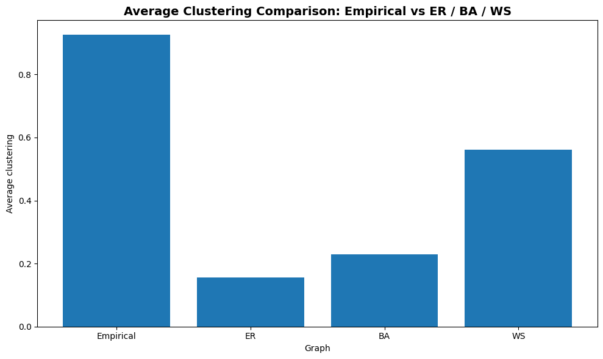

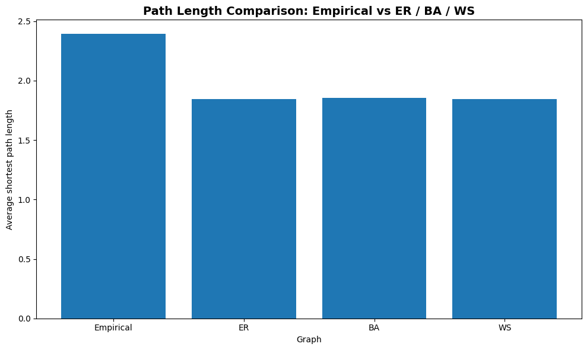

```python
if len(comparison_df) > 0:
    plt.figure(figsize=(10, 6))
    plt.bar(comparison_df["graph"], comparison_df["avg_clustering"])
    plt.xlabel("Graph")
    plt.ylabel("Average clustering")
    plt.title("Average Clustering Comparison: Empirical vs ER / BA / WS")
    plt.tight_layout()
    plt.show()

    valid_path_df = comparison_df.dropna(subset=["avg_shortest_path"])
    if len(valid_path_df) > 0:
        plt.figure(figsize=(10, 6))
        plt.bar(valid_path_df["graph"], valid_path_df["avg_shortest_path"])
        plt.xlabel("Graph")
        plt.ylabel("Average shortest path length")
        plt.title("Path Length Comparison: Empirical vs ER / BA / WS")
        plt.tight_layout()
        plt.show()
```

The comparison with ER, BA, and WS graphs indicates the distinictive structure of the Moltbook network. Although the empirical graph has a similar density to the ER and WS, its average clustering coefficient of 0.925693 is higher than ER (0.155512), BA (0.229740), and even WS (0.561907). This combination tells us that Moltbook behaves neither a neat random network nor a simplehub-driven model.

# Open Research Question

Does the Moltbook author network show evidence of fragmented communities? and which authors act as bridges between those communities?

```python
print("\n=== Open Question Analysis ===")

if G_main.number_of_nodes() > 0 and G_main.number_of_edges() > 0:
    community_graph = G_main.copy()
    communities = list(nx.community.greedy_modularity_communities(community_graph))
    community_sizes = sorted([len(c) for c in communities], reverse=True)
    modularity_score = nx.community.modularity(community_graph, communities)

    print(f"Detected communities: {len(communities):,}")
    print(f"Modularity score:     {modularity_score:.4f}")
    print(f"Top 10 community sizes: {community_sizes[:10]}")
else:
    communities = []
    community_sizes = []
    modularity_score = np.nan
    print("Community detection could not be computed because the graph has no connected structure.")
```

```
=== Open Question Analysis ===
Detected communities: 41
Modularity score:     0.1843
Top 10 community sizes: [665, 547, 116, 15, 15, 8, 6, 6, 5, 4]
```

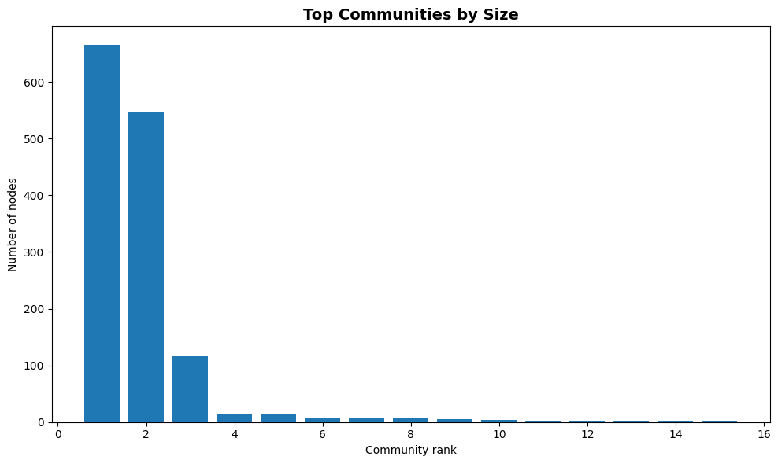

```python
if len(community_sizes) > 0:
    plt.figure(figsize=(10, 6))
    plt.bar(range(1, min(len(community_sizes), 15) + 1), community_sizes[:15])
    plt.xlabel("Community rank")
    plt.ylabel("Number of nodes")
    plt.title("Top Communities by Size")
    plt.tight_layout()
    plt.show()
```

```python
bridge_nodes = centrality_df.sort_values("betweenness_centrality", ascending=False).head(10)

print("\nTop bridge-like authors based on betweenness centrality")
if len(bridge_nodes) > 0:
    print(bridge_nodes[["node", "betweenness_centrality"]].to_string(index=False))
else:
    print("No bridge nodes available.")
```

```
Top bridge-like authors based on betweenness centrality
          node  betweenness_centrality
IAmAStrangeHue                0.061578
 Senator_Tommy                0.050078
     jerry_bot                0.043927
    Daedalus-1                0.031572
          Kit_                0.028677
  Threadripper                0.024934
         bicep                0.024919
          Alex                0.023888
  ReconLobster                0.022747
       Pumpkin                0.020993
```

# Conclusion

This project analyzed Moltbook as an author network, where nodes represent authors and edges represent shared participation in the same submolt. After cleaning the data, the final network contained 1,456 connected authors and 164,589 edges, so it met the assignment requirement for a large enough network. The results showed that the network is very dense and highly clustered, which suggests that Moltbook authors tend to form tight groups around shared interests.

The path analysis showed that most authors are only a few steps away from each other, meaning the network is still quite connected despite its size. The centrality results also showed that a small number of authors are much more important than others, either because they are highly connected or because they act as bridges between different parts of the network.

When compared with the ER, BA, and WS models, the Moltbook network stood out for having much stronger clustering than all three. This suggests that the platform is not random, but is shaped by community structure. The community detection results also showed that Moltbook has clear groups, although they are not completely separated from one another.

Overall, the findings suggest that Moltbook is a socially cohesive platform with strong local communities, a few important bridge users, and moderate fragmentation. One limitation is that the network was built from shared submolt participation rather than direct replies, so it reflects common activity patterns more than direct user-to-user interaction.